# BI586_dada2_analysis

Elsa Brenner, Jamie Poirier, Erica Sun

March 9, 2021

VERSION CONTROL:

```r
R.version
```

```
##                _
## platform       x86_64-apple-darwin17.0
## arch           x86_64
## os             darwin17.0
## system         x86_64, darwin17.0
## status
## major          4
## minor          0.4
## year           2021
## month          02
## day            15
## svn rev        80002
## language       R
## version.string R version 4.0.4 (2021-02-15)
## nickname       Lost Library Book
```

```r
packageVersion("dada2") #1.16.0
```

```
## [1] '1.16.0'
```

```r
packageVersion("ggplot2") #3.3.3
```

```
## [1] '3.3.3'
```

```r
packageVersion("ShortRead") #1.46.0
```

```
## [1] '1.46.0'
```

```r
packageVersion("phyloseq") #1.32.0
```

```
## [1] '1.32.0'
```

# **INTRODUCTION:**

For this assignment, we used the data used in [“Patterns of environmental variability influence coral‐associated bacterial and algal communities on the Mesoamerican Barrier Reef”](https://onlinelibrary.wiley.com/doi/full/10.1111/mec.15497) published in *Molecular Ecology* by L. Speare, et. al. (2020).

Speare et. al.’s study explores the bacterial and algal symbionts associated with two species of Caribbean stony corals– *Siderastrea siderea* and *Siderastrea radians* found on the Belize Mesoamerican Barrier Reef (Figure 1). Their study aimed to investigate the factors that determine variability in Bacterial Community Composition (BCC); specifically how BCC varried across two species in the same genus, and how BCC varried across location, both in different sites, and inshore v. offshore at specific sites.

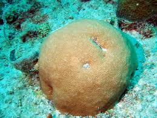

Figure 1: photo via *Coralpedia* (The University of Warwick)

For their analysis, Speare et. al. amplified a 444 bp section of the V3-V4 variable regions of the 16S gene. The 16S rRNA gene is commonly used in DNA barcoding of bacteria, and was therefore an optimal choice for investigating coral BCC.

In brief summary, the team found that BCC varried significantly between species, and from site-to-site. However, their findings explained >11% of variability, and future investigation into the factors determining BCC and algal composition are necessary (Speare et. al., 2020).

## For this assignment, we looked at subsample of Speare et. al.’s data, 10 *Siderastrea siderea*, 5 from inshore locations and 5 from offshore locations, and accessed the genomic data from the [NCBI Sequence Read Archive (SRA)](https://www.ncbi.nlm.nih.gov/sra).

# **STEP-BY-STEP METHODS AND DATA ANALYSIS:**

## Getting Ready

### Downloading .fastq files from NCBI SRA

First, we have to download our data from [NCBI BioSample](https://www.ncbi.nlm.nih.gov/biosample?LinkName=bioproject_biosample_all&from_uid=628692). We chose 5 offshore and 5 inshore samples of *Siderastrea siderea* for our analysis. Now we can download all the sample number (starting with SRR) directly on NCBI by using the “send to” feature with settings: Format = “Accessions List” and Sort By = “Default order”. Then save the accessions list with file name srafile.

Now we are ready to download our sequences.

```bash
$ prefetch --option-file srafile
```

We just downloaded all the sample runs as .sra files! Now we have to convert them into .fastq

```bash
# First let's make a directory to store our output .fastq files
$ mkdir sraout
# Convert them to .fastq and store the output in the sraout director
$ fastq-dump --split-files ./SRR* -O sraout/
```

That’s it! Now we have all of our sampels in .fastq format and we’re ready to run the dada2 pipeline!

### Loading Required Packages

First we have to install the packages.

```r
if (!requireNamespace("BiocManager", quietly = TRUE))
  install.packages("BiocManager")
BiocManager::install("dada2")
BiocManager::install('vegan')
BiocManager::install('phyloseq')
```

Then load the required packages.

```r
library(dada2)
library(ShortRead)
library(ggplot2)
library(phyloseq)
```

### Set the working directory

We need to make sure that all the files we are working with are in the same directory.

```r
# Make sure to change this to the directory you're working in!
setwd('/Users/ericasun/Documents/GitHub/BI586-Project1/') # for Erica's local computer
# setwd('/usr4/bs831/ericasun/BI586/BI586-Project1') for Erica's SCC
```

## Trimming and Filtering

Set our current working directory as path, and set all of the files in there as fns.

```r
path <- '/Users/ericasun/Documents/GitHub/BI586-Project1/' # for Erica's local computer
# path <- '/usr4/bs831/ericasun/BI586/BI586-Project1' # for Erica's SCC
fns <- list.files(path)
```

Align every file that ends with .fastq as fastqs and sort them.

```r
fastqs <- fns[grepl(".fastq$", fns)]
fastqs <- sort(fastqs)
# Now let's take a look to ensure we're on the right track!
fastqs
```

```
##  [1] "SRR11620710_1.fastq" "SRR11620711_1.fastq" "SRR11620712_1.fastq"
##  [4] "SRR11620714_1.fastq" "SRR11620715_1.fastq" "SRR11620719_1.fastq"
##  [7] "SRR11620720_1.fastq" "SRR11620721_1.fastq" "SRR11620733_1.fastq"
## [10] "SRR11620734_1.fastq"
```

Get the sample names, so essentailly just everything before "_1.fastq"

```r
sample.names <- sapply(strsplit(fastqs, "_1.fastq"), `[`, 1)
# Let's take a look
sample.names
```

```
##  [1] "SRR11620710" "SRR11620711" "SRR11620712" "SRR11620714" "SRR11620715"
##  [6] "SRR11620719" "SRR11620720" "SRR11620721" "SRR11620733" "SRR11620734"
```

Assign the full path as fnFs

```r
fnFs <- file.path(path, fastqs)
head(fnFs) #Let's just take a peak this time
```

```
## [1] "/Users/ericasun/Documents/GitHub/BI586-Project1//SRR11620710_1.fastq"
## [2] "/Users/ericasun/Documents/GitHub/BI586-Project1//SRR11620711_1.fastq"
## [3] "/Users/ericasun/Documents/GitHub/BI586-Project1//SRR11620712_1.fastq"
## [4] "/Users/ericasun/Documents/GitHub/BI586-Project1//SRR11620714_1.fastq"
## [5] "/Users/ericasun/Documents/GitHub/BI586-Project1//SRR11620715_1.fastq"
## [6] "/Users/ericasun/Documents/GitHub/BI586-Project1//SRR11620719_1.fastq"
```

### Visualize Raw Data

Let’s take a look at quality profile

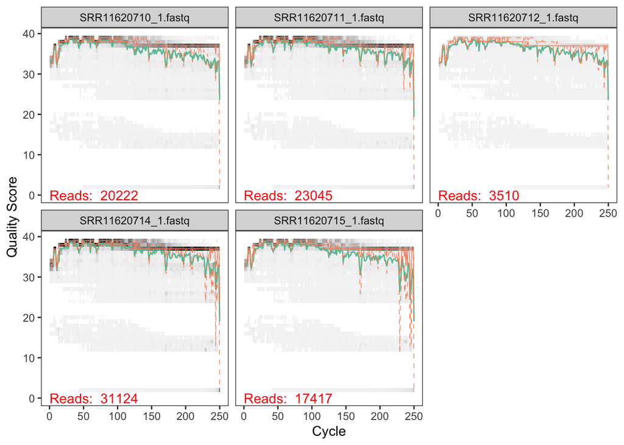

```r
# Let's start with the first five reads, which are the offshores.
dada2::plotQualityProfile(fnFs[c(1,2,3,4,5)])
```

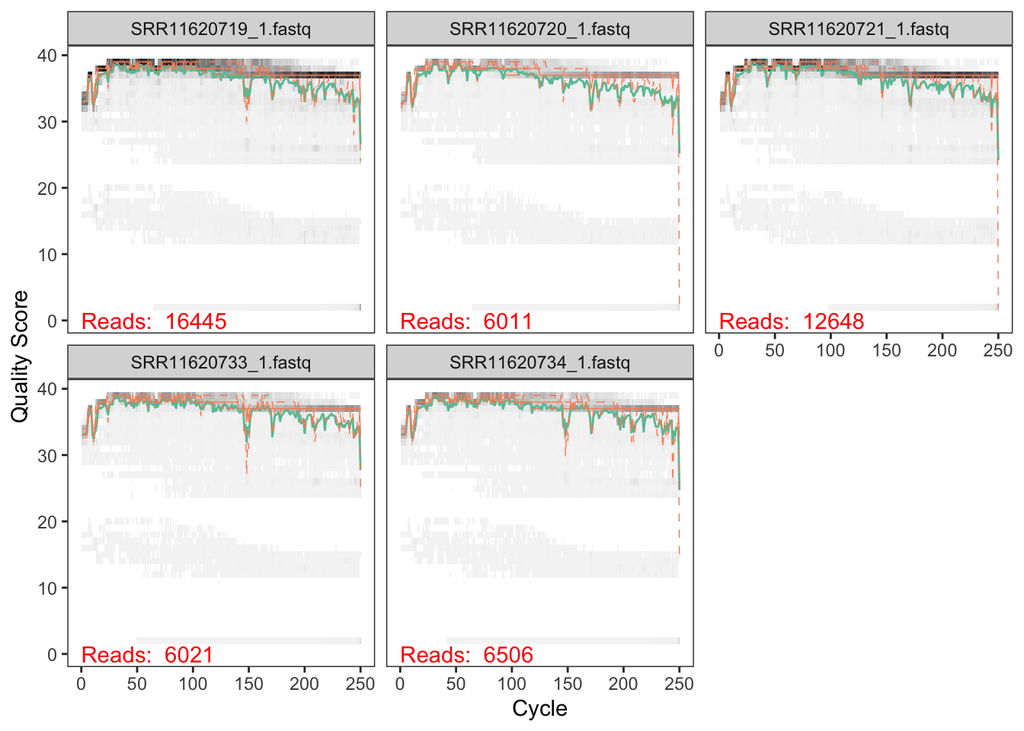

```r
# Then let's look at the inshore ones
dada2::plotQualityProfile(fnFs[c(6,7,8,9,10)])
```

According to the output, we should trim our data at 200. Let’s create a directory and filenames of the trimmed fastqs.

```r
filt_path <- file.path(path, "trimmed")
if(!file_test("-d", filt_path)) dir.create(filt_path)
filtFs <- file.path(filt_path, paste0(sample.names, "_filt.fastq.gz"))
```

### Filtering

```r
out <- dada2::filterAndTrim(fnFs, filtFs, truncLen= 200, #end of single end reads = approx. 300 bp
                     maxN=0, #DADA does not allow Ns
                     maxEE=1, #allow 1 expected errors, where EE = sum(10^(-Q/10)); more conservative, model converges
                     truncQ=2, #standard filtering parameters
                     trimLeft=20, #20 nucleotides are removed from the start of each read: The degenerative bases + the primer
                     rm.phix=TRUE, #remove reads matching phiX genome
                     compress=TRUE, multithread=TRUE) # On Windows set multithread=FALSE

head(out)
```

```
##                     reads.in reads.out
## SRR11620710_1.fastq    20222     18895
## SRR11620711_1.fastq    23045     22351
## SRR11620712_1.fastq     3510      3389
## SRR11620714_1.fastq    31124     30144
## SRR11620715_1.fastq    17417     16363
## SRR11620719_1.fastq    16445     15928
```

```r
tail(out)
```

```
##                     reads.in reads.out
## SRR11620715_1.fastq    17417     16363
## SRR11620719_1.fastq    16445     15928
## SRR11620720_1.fastq     6011      5742
## SRR11620721_1.fastq    12648     12239
## SRR11620733_1.fastq     6021      5864
## SRR11620734_1.fastq     6506      6351
```

## Learn Error Rates

Every amplicon dataset has a different set of error rates, the learnError method can learn the error model from the data. The algorithm must begin with an initial guess, for which the maximum possible error rates in the data are used. For example, when the most abundant sequence is correct, and all the rest are errors.  
Some things to keep in mind –  
* Error rates should decline with increasing qual score * red line is based on definition of quality score alone * black line is estimated error rate after convergence

```r
#setDadaOpt(MAX_CONSIST=30) #increase number of cycles to allow convergence #Actually not sure what this is doing? Ask for help.
errF <- dada2::learnErrors(filtFs, multithread=TRUE)
```

```
## 24707880 total bases in 137266 reads from 10 samples will be used for learning the error rates.
```

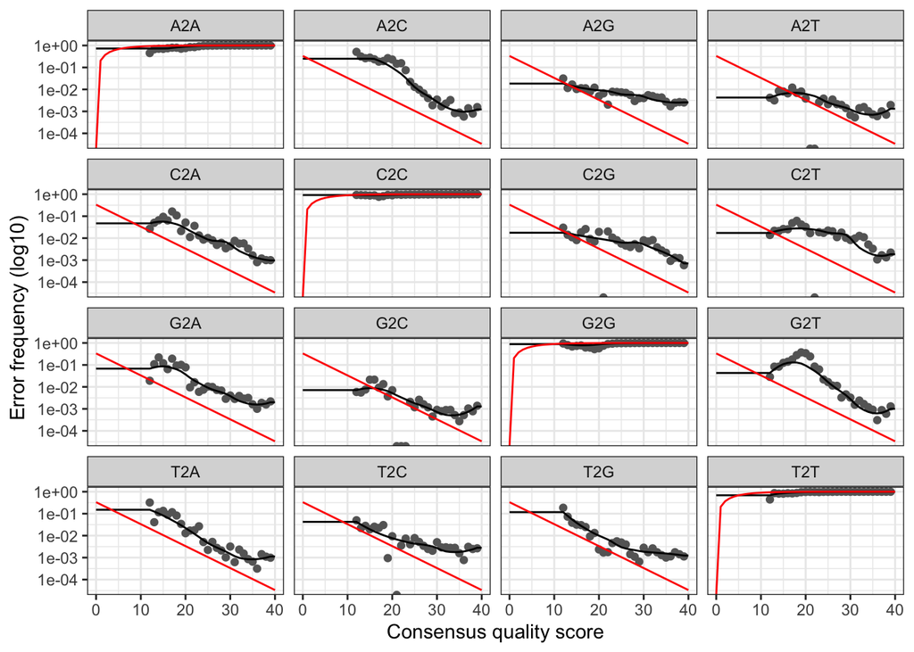

```r
dada2::plotErrors(errF, nominalQ=TRUE)
```

## Dereplicate Reads

Dereplication combines identical sequences into one “unique sequence”. “Abundance” is the number of reads with that unique sequence. This is done to reduce computation time by eliminating redundant comparisons. DADA2 has a summary of the quality information associated with each unique sequence. To increase DADA2’s accuracy, this quality information tells the error model of the subsequent denoising step.

```r
derepFs <- dada2::derepFastq(filtFs, verbose=TRUE)
```

```
## Dereplicating sequence entries in Fastq file: /Users/ericasun/Documents/GitHub/BI586-Project1//trimmed/SRR11620710_filt.fastq.gz
```

```
## Encountered 4463 unique sequences from 18895 total sequences read.
```

```
## Dereplicating sequence entries in Fastq file: /Users/ericasun/Documents/GitHub/BI586-Project1//trimmed/SRR11620711_filt.fastq.gz
```

```
## Encountered 4730 unique sequences from 22351 total sequences read.
```

```
## Dereplicating sequence entries in Fastq file: /Users/ericasun/Documents/GitHub/BI586-Project1//trimmed/SRR11620712_filt.fastq.gz
```

```
## Encountered 1443 unique sequences from 3389 total sequences read.
```

```
## Dereplicating sequence entries in Fastq file: /Users/ericasun/Documents/GitHub/BI586-Project1//trimmed/SRR11620714_filt.fastq.gz
```

```
## Encountered 6599 unique sequences from 30144 total sequences read.
```

```
## Dereplicating sequence entries in Fastq file: /Users/ericasun/Documents/GitHub/BI586-Project1//trimmed/SRR11620715_filt.fastq.gz
```

```
## Encountered 3381 unique sequences from 16363 total sequences read.
```

```
## Dereplicating sequence entries in Fastq file: /Users/ericasun/Documents/GitHub/BI586-Project1//trimmed/SRR11620719_filt.fastq.gz
```

```
## Encountered 4400 unique sequences from 15928 total sequences read.
```

```
## Dereplicating sequence entries in Fastq file: /Users/ericasun/Documents/GitHub/BI586-Project1//trimmed/SRR11620720_filt.fastq.gz
```

```
## Encountered 1995 unique sequences from 5742 total sequences read.
```

```
## Dereplicating sequence entries in Fastq file: /Users/ericasun/Documents/GitHub/BI586-Project1//trimmed/SRR11620721_filt.fastq.gz
```

```
## Encountered 3372 unique sequences from 12239 total sequences read.
```

```
## Dereplicating sequence entries in Fastq file: /Users/ericasun/Documents/GitHub/BI586-Project1//trimmed/SRR11620733_filt.fastq.gz
```

```
## Encountered 1667 unique sequences from 5864 total sequences read.
```

```
## Dereplicating sequence entries in Fastq file: /Users/ericasun/Documents/GitHub/BI586-Project1//trimmed/SRR11620734_filt.fastq.gz
```

```
## Encountered 1758 unique sequences from 6351 total sequences read.
```

```r
# Naming the dereplicated-class objects by the sample names
names(derepFs) <- sample.names
```

## Infer Sequence Variants

```r
dadaFs <- dada2::dada(derepFs, err=errF, multithread=TRUE)
```

```
## Sample 1 - 18895 reads in 4463 unique sequences.
## Sample 2 - 22351 reads in 4730 unique sequences.
## Sample 3 - 3389 reads in 1443 unique sequences.
## Sample 4 - 30144 reads in 6599 unique sequences.
## Sample 5 - 16363 reads in 3381 unique sequences.
## Sample 6 - 15928 reads in 4400 unique sequences.
## Sample 7 - 5742 reads in 1995 unique sequences.
## Sample 8 - 12239 reads in 3372 unique sequences.
## Sample 9 - 5864 reads in 1667 unique sequences.
## Sample 10 - 6351 reads in 1758 unique sequences.
```

Now, let’s take a look at the data class object by sample. This will tell us how many “real” variants there are in the unique input seqs.

```r
dadaFs[[1]]
```

```
## dada-class: object describing DADA2 denoising results
## 144 sequence variants were inferred from 4463 input unique sequences.
## Key parameters: OMEGA_A = 1e-40, OMEGA_C = 1e-40, BAND_SIZE = 16
```

```r
dadaFs[[10]]
```

```
## dada-class: object describing DADA2 denoising results
## 80 sequence variants were inferred from 1758 input unique sequences.
## Key parameters: OMEGA_A = 1e-40, OMEGA_C = 1e-40, BAND_SIZE = 16
```

```r
seqtab <- dada2::makeSequenceTable(dadaFs)
#head(seqtab)
```

## Remove Chimeras

We have removed the substitution and idel errors, but there are still chimeras. So we’re going to remove them in this step. The accuracy of the sequences after denoisying makes identifying chimeras easier. All sequences can be exactly reconstructed as a bimera (two-parent chimera) from more abundant sequences.

```r
seqtab.nochim <- dada2::removeBimeraDenovo(seqtab, method="consensus", multithread=TRUE, verbose=TRUE)
```

```
## Identified 6 bimeras out of 940 input sequences.
```

```r
dim(seqtab.nochim) # dim function retrieve or set the dimension of an object
```

```
## [1]  10 934
```

We identified 6 bimeras out of 940 input sequences. This is how much sample remain after the removal of chimera. Most reads still remain.

```r
sum(seqtab.nochim)/sum(seqtab)
```

```
## [1] 0.9956432
```

For our sample, the ration was 0.9956432 with 6 bimeras. Let’s output this result as a .csv file

```r
write.csv(seqtab,file="dadaFs_seqtab.csv")
write.csv(seqtab.nochim,file="dadaFs_nochim.csv")
```

## Track Read Stats

```r
getN <- function(x) sum(dada2::getUniques(x))
track <- cbind(out, sapply(dadaFs, getN), sapply(dadaFs, getN), rowSums(seqtab), rowSums(seqtab.nochim))
colnames(track) <- c("input", "filtered", "denoised", "merged", "tabled", "nonchim")
rownames(track) <- sample.names
head(track)
```

```
##             input filtered denoised merged tabled nonchim
## SRR11620710 20222    18895    18851  18851  18851   18851
## SRR11620711 23045    22351    22341  22341  22341   22257
## SRR11620712  3510     3389     3222   3222   3222    3222
## SRR11620714 31124    30144    30072  30072  30072   29708
## SRR11620715 17417    16363    16341  16341  16341   16269
## SRR11620719 16445    15928    15859  15859  15859   15859
```

```r
tail(track)
```

```
##             input filtered denoised merged tabled nonchim
## SRR11620715 17417    16363    16341  16341  16341   16269
## SRR11620719 16445    15928    15859  15859  15859   15859
## SRR11620720  6011     5742     5555   5555   5555    5480
## SRR11620721 12648    12239    12161  12161  12161   12161
## SRR11620733  6021     5864     5825   5825   5825    5825
## SRR11620734  6506     6351     6340   6340   6340    6340
```

```r
write.csv(track,file="ReadFilterStats_AllData_final.csv",row.names=TRUE,quote=FALSE)
```

## Assign Taxonomy

DADA2 uses naive Bayesian classifier method to assign taxonomy. The assignTaxonomy function takes as input a set of sequences to be classified and a tranning set of reference sequence with known taxonomy. It outputs taxonomic assignments with at least minBoot bootstrap confidence.

```r
taxa <- dada2::assignTaxonomy(seqtab.nochim, "silva_nr99_v138_train_set.fa", minBoot=70,multithread=TRUE,tryRC=TRUE,outputBootstraps=FALSE)
#minboot should be 70
#Obtain a csv file for the taxonomy so that it's easier to map the sequences for the heatmap.
taxa <- dada2::addSpecies(taxa,"silva_species_assignment_v138.fa")
write.csv(taxa, file="taxa.csv",row.name=TRUE,quote=FALSE)
unname(head(taxa, 30))
unname(taxa)

# Save outputs as .rds to save some spaces
saveRDS(seqtab.nochim, file="final_seqtab_nochim.rds")
saveRDS(taxa, file="final_taxa_blastCorrected.rds")

# If you need to read in previously saved datafiles
seqtab.nochim <- readRDS("final_seqtab_nochim.rds")
taxa <- readRDS("final_taxa_blastCorrected.rds")
head(taxa)
```

## Handoff to Phyloseq

Pyloseq is going to give us some visualization! Import the required libraries.

```r
library(phyloseq)
library(ggplot2)
```

Now we can import dataframe holding sample information. Then we can have the samples in the same order as the seqtab file in the rows, variables as columns

```r
samdf<-read.csv("variabletable.csv")
head(samdf)
head(seqtab.nochim)
head(taxa)
rownames(samdf) <- samdf$sample
```

We’re ready to construct phyloseq object now!(straightforward from dada2 outputs)

```r
ps <- phyloseq(otu_table(seqtab.nochim, taxa_are_rows=FALSE),
               sample_names(samdf),
               tax_table(taxa))
ps
```

```
## phyloseq-class experiment-level object
## otu_table()   OTU Table:         [ 934 taxa and 10 samples ]
## tax_table()   Taxonomy Table:    [ 934 taxa by 7 taxonomic ranks ]
```

replace sequences with shorter names (correspondence table output below)

```r
ids<-taxa_names(ps)
ids <- paste0("sq",seq(1, length(colnames(seqtab.nochim))))
colnames(seqtab.nochim) <- ids
```

Let’s visualize using Bar-plots

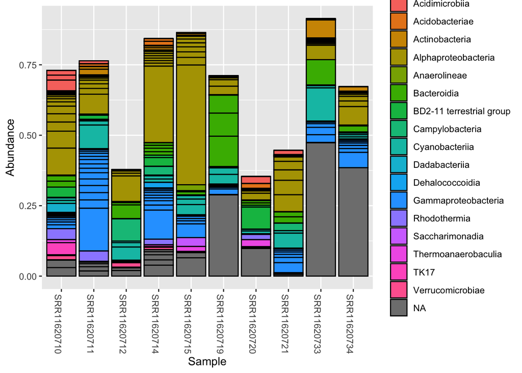

```r
top90 <- names(sort(taxa_sums(ps), decreasing=TRUE))[1:90]
ps.top90 <- transform_sample_counts(ps, function(OTU) OTU/sum(OTU))
ps.top90 <- prune_taxa(top90, ps.top90)

plot_bar(ps.top90, x="Sample", fill="Class")
```

Ideally, we will want to visusalize via counts rather than abundances. However this is not working. Since we have the other two abundance plots, we decided to just skip this one.

```r
plot_bar(ps, x = "sample", fill= "Class")
```

Obtain a csv file for the phyloseq data. Will give you the abundances for each sample and class. Useful for constructing the heatmap. Also, enables you to use ggplot, and construct more aesthetically pleasing plot.

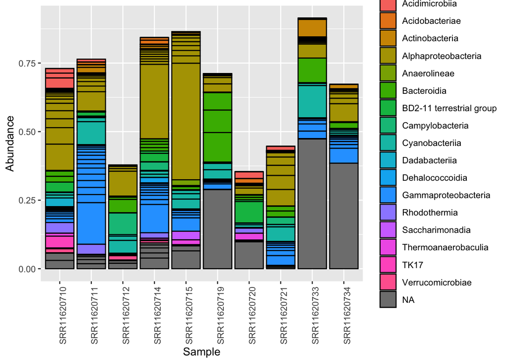

```r
psz <- psmelt(ps.top90)
write.csv(psz, file="Phyloseqoutputfinal.csv")
p <- ggplot(psz, aes(x=Sample, y=Abundance, fill=Class))
p + geom_bar(stat="identity", colour="black") + theme(axis.text.x = element_text(angle = 90))
```

# **REFERENCES:**

Coralpedia - Your guidie to caribbean corals and sponges. (2021). Retrieved March 05, 2021, from https://coralpedia.bio.warwick.ac.uk/en/corals/siderastrea_siderea

Speare, L, Davies, SW, Balmonte, JP, Baumann, J, Castillo, KD. Patterns of environmental variability influence coral‐associated bacterial and algal communities on the Mesoamerican Barrier Reef. Mol Ecol. 2020; 29: 2334– 2348. https://doi.org/10.1111/mec.15497

[WoRMS Editorial Board](http://www.marinespecies.org/aphia.php?p=popup&name=citation) (2021). World Register of Marine Species. Available from http://www.marinespecies.org at VLIZ. Accessed 2021-03-05. doi:10.14284/170